# Bechmarking (fast) **dplyr** alternatives

# 1 Introduction

**dplyr** (https://dplyr.tidyverse.org/) is the most popular package for data manipulation in the R ecosystem.

This notebook seeks to compare the speed of improved frameworks (packages) that perform similar tasks:  
- Apache **arrow**: https://arrow.apache.org/docs/r/  
- **multidplyr** (dplyr with parallel cores): https://multidplyr.tidyverse.org/  
- **data.table**: https://github.com/Rdatatable/data.table  
- **dtplyr** (combines dpylr with datatable): https://dtplyr.tidyverse.org/  
- **tidytable** (also dplyr & datatable): https://github.com/markfairbanks/tidytable  
- **collapse**: https://sebkrantz.github.io/collapse/

Below, we perform two tasks, namely two pivot tables along two axes.  
Naturally, these are very precise examples and are not sufficient to conclude definitely.

The **dataset** can be downloaded at https://dachxiu.chicagobooth.edu/download/datashare.zip  
It comprises financial information about 31K+ firms over 768 months. We will thus test grouping along these 2 dimensions.  
**NOTE**: we use **fread** to import the .csv: https://datatable.readthedocs.io/en/latest/api/dt/fread.html

I thank [Mark Fairbanks](https://github.com/markfairbanks) and [Sebastian Krantz](https://github.com/SebKrantz) for helpful comments.

```r
library(tidyverse)
library(data.table)
library(arrow)
library(dtplyr)
library(tidytable)
library(collapse)
library(multidplyr)
library(microbenchmark)
data <- fread("datashare_2021.csv") %>% data.frame()
```

# 2 Data preparation

One issue with **multidplyr** is the pre-processing stage, which is slightly lengthy.  
In all transparency, the authors of the packages acknowledge that it is the most impressive with very large datasets (10M+ rows).

```r
data_multi_n <- function(data, m){
    cluster <- new_cluster(m)                                     # for multidplyr
    data %>% group_by(DATE) %>% partition(cluster)
}

microbenchmark(
    arrow = write_parquet(data, sink = "data.parquet"),           # arrow
    multidplyr = data_multi_n(data, 4),                           # multidplyr
    tidytable = data.table(data),                                 # data.table & tidytable
    dtplyr = lazy_dt(data),                                       # dtplyr
    times = 10,
    unit = "seconds") %>%
    summary()
```

| expr | min | lq | mean | median | uq | max | neval |
| --- | --- | --- | --- | --- | --- | --- | --- |
| arrow | 12.1074129 | 12.125918 | 12.293681 | 12.211368 | 12.470099 | 12.778913 | 10 |
| multidplyr | 14.4815546 | 14.494053 | 15.398404 | 15.466416 | 15.665112 | 16.505704 | 10 |
| tidytable | 2.0439909 | 2.555480 | 2.982242 | 3.049378 | 3.178886 | 3.894809 | 10 |
| dtplyr | 0.7722297 | 1.307555 | 1.536715 | 1.494366 | 1.910549 | 2.071766 | 10 |

Below, we re-execute the operations to keep the objects in the environment.

```r
write_parquet(data, sink = "data.parquet")
cluster <- new_cluster(4)                                            # for multidplyr
data_multi <- data %>% group_by(DATE) %>% partition(cluster)
data_dt <- data.table(data)                                          # for data.table & tidytable
data_table <- lazy_dt(data)

data_parquet <- read_parquet("data.parquet")                         # for arrow
```

# 3 Pivoting along a short axis

```r
bench <- microbenchmark(
    dplyr = data %>% dplyr::group_by(DATE) %>% dplyr::summarise(m = mean(is.finite(mom1m))),                            # dplyr
    arrow = data_parquet %>% dplyr::group_by(DATE) %>% dplyr::summarise(m = mean(is.finite(mom1m))),                    # arrow
    multidplyr = data_multi %>% dplyr::group_by(DATE) %>% dplyr::summarise(m = mean(is.finite(mom1m))) %>% collect(),   # multidplyr
    collapse = data %>% fgroup_by(DATE) %>% fsummarise(m = fmean(is.finite(mom1m))),                                    # collapse
    tidytable = data_dt %>% summarise(m = mean(is.finite(mom1m)), .by = DATE),                                          # tidytable
    dtplyr = data_table %>% dplyr::group_by(DATE) %>% dplyr::summarise(m = mean(is.finite(mom1m))) %>% as.data.table(), # dtplyr
    data.table = data_dt[, mean(is.finite(mom1m)), by = "DATE"],                                                        # data.table
    times = 60,
    unit = "seconds")
```

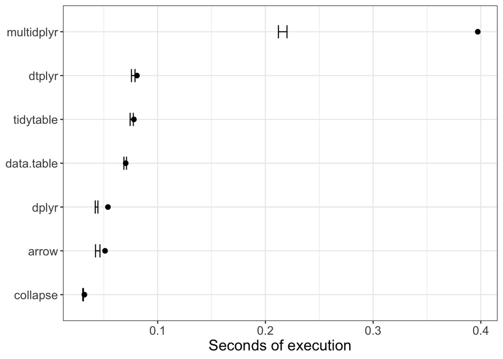

```r
bench %>%
    summary() %>%
    ggplot(aes(y = reorder(expr, mean))) + theme_bw() +
    geom_point(aes(x = mean), size = 2) + xlab("Seconds of execution") +
    geom_errorbar(aes(xmin = lq, xmax = uq), width = 0.3) +
    theme(axis.title.y = element_blank(),
          text = element_text(size = 15))
```

The average point is shown with the IQR (inter-quartile range).  
The original implementation of **dplyr** (in C++) is competitive in this exercise.

# 4 Pivoting along the other dimension

In the second exercise, there are much more groups along which to compute the number of well-defined points.

```r
data_multi <- data %>% group_by(permno) %>% partition(cluster)
bench <- microbenchmark(
    dplyr = data %>% dplyr::group_by(permno) %>% dplyr::summarise(m = mean(is.finite(mom1m))),                            # dplyr
    arrow = data_parquet %>% dplyr::group_by(permno) %>% dplyr::summarise(m = mean(is.finite(mom1m))),                    # arrow
    multidplyr = data_multi %>% dplyr::group_by(permno) %>% dplyr::summarise(m = mean(is.finite(mom1m))) %>% collect(),   # multidplyr
    collapse = data %>% fgroup_by(permno) %>% fsummarise(m = fmean(is.finite(mom1m))),                                    # collapse
    tidytable = data_dt %>% summarise(m = mean(is.finite(mom1m)), .by = permno),                                          # tidytable
    dtplyr = data_table %>% dplyr::group_by(permno) %>% dplyr::summarise(m = mean(is.finite(mom1m))) %>% as.data.table(), # dtplyr
    data.table = data_dt[, mean(is.finite(mom1m)), by = "permno"],                                                        # data.table
    times = 50,
    unit = "seconds")
```

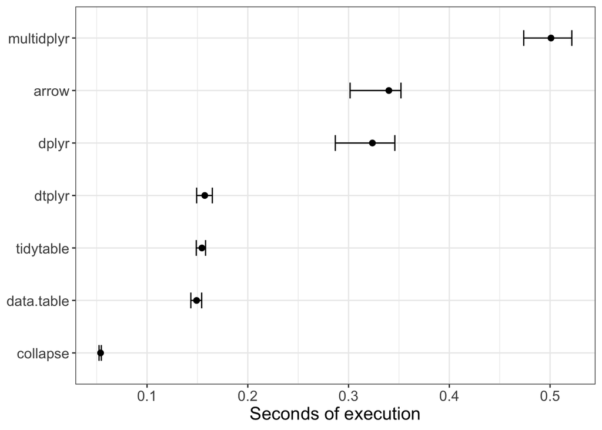

```r
bench %>%
    summary() %>%
    ggplot(aes(y = reorder(expr, mean))) + theme_bw() +
    geom_point(aes(x = mean), size = 2) + xlab("Seconds of execution") +
    geom_errorbar(aes(xmin = lq, xmax = uq), width = 0.3) +
    theme(axis.title.y = element_blank(),
          text = element_text(size = 15))
```

The initial package **dplyr** is now less appealing, compared to collapse, tidytable and dtplyr.

Finally, we test an even lengthier exercise in which the summary is asked for *all* columns in the dataset.

```r
prop_fin <- function(x){mean(is.finite(x))}
bench <- microbenchmark(
    dplyr = data %>% dplyr::group_by(DATE) %>% dplyr::summarise(across(everything(), prop_fin)), # dplyr
    dtplyr = data_table %>% dplyr::group_by(DATE) %>%
        dplyr::summarise(across(everything(), prop_fin)) %>% as.data.table(),                    # dtplyr
    collapse = data %>% ftransformv(-DATE, is.finite) %>% fgroup_by(DATE) %>% fmean(),           # collapse
    times = 50,
    unit = "seconds")
summary(bench)
```

| expr | min | lq | mean | median | uq | max | neval |
| --- | --- | --- | --- | --- | --- | --- | --- |
| dplyr | 2.644738 | 3.050272 | 3.323984 | 3.274942 | 3.521120 | 4.349464 | 50 |
| dtplyr | 1.643432 | 1.724856 | 2.034350 | 1.805122 | 2.227978 | 3.405955 | 50 |
| collapse | 1.662085 | 1.675199 | 1.932099 | 1.688387 | 1.994454 | 3.041505 | 50 |

**dtplyr** and **collapse** remain ahead of **dplyr**.

# 5 Preliminary conclusion

These results are contingent on the size of the dataset (~4M), which is intermediate between *small data* and *big data*.